# Vehicle_Silhouette

**Data Description:**

The data contains features extracted from the silhouette of vehicles in different angles. Four "Corgie" model vehicles were used for the experiment: a double decker bus, Cheverolet van, Saab 9000 and an Opel Manta 400 cars. This particular combination of vehicles was chosen with the expectation that the bus, van and either one of the cars would be readily distinguishable, but it would be more difficult to distinguish between the cars.

**Context:** The purpose is to classify a given silhouette as one of three types of vehicle, using a set of features extracted from the silhouette

**Attribute Information:**

● Compactness (average perim)**2/area

● Circularity (average radius)**2/area

● Distance circularity area / (av.distance from order)**2

● Radius ratio (max.rad.min.rad)/av.radius

● PR.axis aspect ratio(minor axis)/(major axis)

● Max.length aspect ratio (length prep.max length) / (max length)

● Scatter ratio (inertia about minor axis) / (inertia about major axis)

● Elongatedness area/(shrink width)**2

● Pr.axis regularility area / (pr.axis length*pr.axix.width)

● Max.length regularity area/(max.length*length.prep to this)

● Scaled variance (2nd order moment about minor axis)/area along major axis

● Scaled radius of Gyration (mavar+mivar)/area

●Skewness about ( 3rd order moment about major axis)/sigma_min**3 major axis

●Skewness about ( 3rd order moment about minor axis)/sigma_maj**3 minor axis

●Skewness about ( 4th order moment about major axis)/sigma_min**4 minor axis

All the features are geometric features extracted from the silhouette.  
All are numeric in nature.

```python
import pandas as pd
import numpy as np
import matplotlib.pyplot as plt
import seaborn as sns
```

```python
data=pd.read_csv("vehicle-1.csv")
data.head(100)
```

|  | compactness | circularity | distance_circularity | radius_ratio | pr.axis_aspect_ratio | max.length_aspect_ratio | scatter_ratio | elongatedness | pr.axis_rectangularity | max.length_rectangularity | scaled_variance | scaled_variance.1 | scaled_radius_of_gyration | scaled_radius_of_gyration.1 | skewness_about | skewness_about.1 | skewness_about.2 | hollows_ratio | class |
| --- | --- | --- | --- | --- | --- | --- | --- | --- | --- | --- | --- | --- | --- | --- | --- | --- | --- | --- | --- |
| 0 | 95 | 48.0 | 83.0 | 178.0 | 72.0 | 10 | 162.0 | 42.0 | 20.0 | 159 | 176.0 | 379.0 | 184.0 | 70.0 | 6.0 | 16.0 | 187.0 | 197 | van |
| 1 | 91 | 41.0 | 84.0 | 141.0 | 57.0 | 9 | 149.0 | 45.0 | 19.0 | 143 | 170.0 | 330.0 | 158.0 | 72.0 | 9.0 | 14.0 | 189.0 | 199 | van |
| 2 | 104 | 50.0 | 106.0 | 209.0 | 66.0 | 10 | 207.0 | 32.0 | 23.0 | 158 | 223.0 | 635.0 | 220.0 | 73.0 | 14.0 | 9.0 | 188.0 | 196 | car |
| 3 | 93 | 41.0 | 82.0 | 159.0 | 63.0 | 9 | 144.0 | 46.0 | 19.0 | 143 | 160.0 | 309.0 | 127.0 | 63.0 | 6.0 | 10.0 | 199.0 | 207 | van |
| 4 | 85 | 44.0 | 70.0 | 205.0 | 103.0 | 52 | 149.0 | 45.0 | 19.0 | 144 | 241.0 | 325.0 | 188.0 | 127.0 | 9.0 | 11.0 | 180.0 | 183 | bus |
| 5 | 107 | NaN | 106.0 | 172.0 | 50.0 | 6 | 255.0 | 26.0 | 28.0 | 169 | 280.0 | 957.0 | 264.0 | 85.0 | 5.0 | 9.0 | 181.0 | 183 | bus |
| 6 | 97 | 43.0 | 73.0 | 173.0 | 65.0 | 6 | 153.0 | 42.0 | 19.0 | 143 | 176.0 | 361.0 | 172.0 | 66.0 | 13.0 | 1.0 | 200.0 | 204 | bus |
| 7 | 90 | 43.0 | 66.0 | 157.0 | 65.0 | 9 | 137.0 | 48.0 | 18.0 | 146 | 162.0 | 281.0 | 164.0 | 67.0 | 3.0 | 3.0 | 193.0 | 202 | van |
| 8 | 86 | 34.0 | 62.0 | 140.0 | 61.0 | 7 | 122.0 | 54.0 | 17.0 | 127 | 141.0 | 223.0 | 112.0 | 64.0 | 2.0 | 14.0 | 200.0 | 208 | van |
| 9 | 93 | 44.0 | 98.0 | NaN | 62.0 | 11 | 183.0 | 36.0 | 22.0 | 146 | 202.0 | 505.0 | 152.0 | 64.0 | 4.0 | 14.0 | 195.0 | 204 | car |
| 10 | 86 | 36.0 | 70.0 | 143.0 | 61.0 | 9 | 133.0 | 50.0 | 18.0 | 130 | 153.0 | 266.0 | 127.0 | 66.0 | 2.0 | 10.0 | 194.0 | 202 | van |
| 11 | 90 | 34.0 | 66.0 | 136.0 | 55.0 | 6 | 123.0 | 54.0 | 17.0 | 118 | 148.0 | 224.0 | 118.0 | 65.0 | 5.0 | 26.0 | 196.0 | 202 | car |
| 12 | 88 | 46.0 | 74.0 | 171.0 | 68.0 | 6 | 152.0 | 43.0 | 19.0 | 148 | 180.0 | 349.0 | 192.0 | 71.0 | 5.0 | 11.0 | 189.0 | 195 | bus |
| 13 | 89 | 42.0 | 85.0 | 144.0 | 58.0 | 10 | 152.0 | 44.0 | 19.0 | 144 | 173.0 | 345.0 | 161.0 | 72.0 | 8.0 | 13.0 | 187.0 | 197 | van |
| 14 | 94 | 49.0 | 79.0 | 203.0 | 71.0 | 5 | 174.0 | 37.0 | 21.0 | 154 | 196.0 | 465.0 | 206.0 | 71.0 | 6.0 | 2.0 | 197.0 | 199 | bus |
| 15 | 96 | 55.0 | 103.0 | 201.0 | 65.0 | 9 | 204.0 | 32.0 | 23.0 | 166 | 227.0 | 624.0 | 246.0 | 74.0 | 6.0 | 2.0 | 186.0 | 194 | car |
| 16 | 89 | 36.0 | 51.0 | 109.0 | 52.0 | 6 | 118.0 | 57.0 | 17.0 | 129 | 137.0 | 206.0 | 125.0 | 80.0 | 2.0 | 14.0 | 181.0 | 185 | van |
| 17 | 99 | 41.0 | 77.0 | 197.0 | 69.0 | 6 | 177.0 | 36.0 | 21.0 | 139 | 202.0 | 485.0 | 151.0 | 72.0 | 4.0 | 10.0 | 198.0 | 199 | bus |
| 18 | 104 | 54.0 | 100.0 | 186.0 | 61.0 | 10 | 216.0 | 31.0 | 24.0 | 173 | 225.0 | 686.0 | 220.0 | 74.0 | 5.0 | 11.0 | 185.0 | 195 | car |
| 19 | 101 | 56.0 | 100.0 | 215.0 | NaN | 10 | 208.0 | 32.0 | 24.0 | 169 | 227.0 | 651.0 | 223.0 | 74.0 | 6.0 | 5.0 | 186.0 | 193 | car |
| 20 | 84 | 47.0 | 75.0 | 153.0 | 64.0 | 6 | 154.0 | 43.0 | 19.0 | 145 | 175.0 | 354.0 | 184.0 | 75.0 | 0.0 | 3.0 | 185.0 | 192 | bus |
| 21 | 84 | 37.0 | 53.0 | 121.0 | 59.0 | 5 | 123.0 | 55.0 | 17.0 | 125 | 141.0 | 221.0 | 133.0 | 82.0 | 7.0 | 1.0 | 179.0 | 183 | van |
| 22 | 94 | 43.0 | 64.0 | 173.0 | 69.0 | 7 | 150.0 | 43.0 | 19.0 | 142 | 169.0 | 344.0 | 177.0 | 68.0 | 9.0 | 1.0 | 199.0 | 206 | bus |
| 23 | 87 | 39.0 | 70.0 | 148.0 | 61.0 | 7 | 143.0 | 46.0 | 18.0 | 136 | 164.0 | 307.0 | 141.0 | 69.0 | 1.0 | 2.0 | 192.0 | 199 | bus |
| 24 | 99 | 53.0 | 105.0 | 219.0 | 66.0 | 11 | 204.0 | 32.0 | 23.0 | 165 | 221.0 | 623.0 | 224.0 | 68.0 | 0.0 | 6.0 | 191.0 | 201 | car |
| 25 | 85 | 45.0 | 80.0 | 154.0 | 64.0 | 9 | 147.0 | 45.0 | 19.0 | 148 | 169.0 | 324.0 | 174.0 | 71.0 | 1.0 | 4.0 | 188.0 | 199 | van |
| 26 | 83 | 36.0 | 54.0 | 119.0 | 57.0 | 6 | 128.0 | 53.0 | 18.0 | 125 | 143.0 | 238.0 | 139.0 | 82.0 | 6.0 | 3.0 | 179.0 | 183 | car |
| 27 | 107 | 54.0 | 98.0 | 203.0 | 65.0 | 11 | 218.0 | 31.0 | 25.0 | 167 | 229.0 | 696.0 | 216.0 | 72.0 | 1.0 | 28.0 | 187.0 | 199 | car |
| 28 | 102 | 45.0 | 85.0 | 193.0 | 64.0 | 6 | 192.0 | 33.0 | 22.0 | 146 | 217.0 | 570.0 | 163.0 | 76.0 | 6.0 | 7.0 | 195.0 | 193 | bus |
| 29 | 80 | 38.0 | 63.0 | 129.0 | 55.0 | 7 | 146.0 | 46.0 | 19.0 | 130 | 168.0 | 314.0 | 158.0 | 83.0 | 9.0 | 20.0 | 180.0 | 185 | car |
| ... | ... | ... | ... | ... | ... | ... | ... | ... | ... | ... | ... | ... | ... | ... | ... | ... | ... | ... | ... |
| 70 | 96 | 55.0 | 98.0 | 161.0 | 54.0 | 10 | 215.0 | 31.0 | NaN | 175 | 226.0 | 683.0 | 221.0 | 76.0 | 3.0 | 6.0 | 185.0 | 193 | car |
| 71 | 97 | 59.0 | 108.0 | 227.0 | 70.0 | 11 | 224.0 | 30.0 | 25.0 | 186 | 225.0 | 732.0 | 218.0 | 70.0 | 10.0 | 25.0 | 186.0 | 198 | car |
| 72 | 92 | 39.0 | 91.0 | 191.0 | 62.0 | 8 | 176.0 | 37.0 | 21.0 | 137 | 196.0 | 466.0 | 151.0 | 67.0 | 3.0 | 23.0 | 192.0 | 200 | car |
| 73 | 73 | 37.0 | 53.0 | 111.0 | 54.0 | 6 | 126.0 | 55.0 | 18.0 | 128 | 135.0 | 227.0 | 147.0 | 82.0 | 1.0 | 15.0 | 176.0 | 184 | car |
| 74 | 89 | 42.0 | 89.0 | 147.0 | 61.0 | 11 | 151.0 | 44.0 | 19.0 | 145 | 170.0 | 338.0 | 163.0 | 72.0 | 11.0 | 23.0 | 187.0 | 199 | van |
| 75 | 101 | 53.0 | 103.0 | 203.0 | 63.0 | 9 | 195.0 | 34.0 | 22.0 | 162 | 210.0 | 571.0 | 210.0 | 68.0 | 5.0 | 5.0 | 191.0 | 198 | car |
| 76 | 91 | 39.0 | 83.0 | 170.0 | 60.0 | 8 | 172.0 | 38.0 | 21.0 | 134 | 197.0 | 445.0 | 152.0 | 72.0 | 0.0 | 10.0 | 188.0 | 194 | car |
| 77 | 86 | 40.0 | 62.0 | 140.0 | 62.0 | 7 | 150.0 | 45.0 | 19.0 | 133 | 165.0 | 330.0 | 173.0 | NaN | 2.0 | 3.0 | 180.0 | 185 | car |
| 78 | 104 | 52.0 | 94.0 | NaN | 66.0 | 5 | 208.0 | 31.0 | 24.0 | 161 | 227.0 | 666.0 | 218.0 | 76.0 | 11.0 | 4.0 | 193.0 | 191 | bus |
| 79 | 89 | 44.0 | 68.0 | 113.0 | 50.0 | 7 | 150.0 | 45.0 | 19.0 | 147 | 171.0 | 328.0 | 189.0 | 88.0 | 6.0 | 5.0 | 179.0 | 182 | bus |
| 80 | 87 | 46.0 | 71.0 | 159.0 | 66.0 | 6 | 151.0 | 44.0 | 19.0 | 146 | 175.0 | 343.0 | 189.0 | 73.0 | 2.0 | 0.0 | 186.0 | 190 | bus |
| 81 | 99 | 51.0 | 92.0 | 203.0 | 65.0 | 5 | 209.0 | 31.0 | 24.0 | 159 | 232.0 | 671.0 | 214.0 | 78.0 | 5.0 | 11.0 | 191.0 | 189 | bus |
| 82 | 94 | 36.0 | 68.0 | 127.0 | 54.0 | 7 | 127.0 | 52.0 | 18.0 | 132 | 155.0 | 242.0 | 116.0 | 66.0 | 1.0 | 2.0 | 195.0 | 196 | van |
| 83 | 79 | 40.0 | 80.0 | 133.0 | 55.0 | 7 | 147.0 | 47.0 | 19.0 | 135 | 172.0 | 311.0 | 144.0 | 76.0 | 8.0 | 30.0 | 181.0 | 193 | car |
| 84 | 89 | 40.0 | 76.0 | 188.0 | 76.0 | 7 | 150.0 | 44.0 | 19.0 | 136 | 174.0 | 342.0 | 148.0 | 72.0 | 3.0 | 8.0 | 193.0 | 197 | bus |
| 85 | 110 | 58.0 | 106.0 | 180.0 | 51.0 | 6 | 261.0 | 26.0 | 28.0 | 171 | 278.0 | 998.0 | 257.0 | 83.0 | 9.0 | 13.0 | 181.0 | 182 | bus |
| 86 | 89 | 41.0 | 84.0 | 141.0 | 58.0 | 9 | 149.0 | 45.0 | 19.0 | 145 | 172.0 | 330.0 | 162.0 | 72.0 | 4.0 | 18.0 | 188.0 | 200 | van |
| 87 | 86 | 37.0 | 60.0 | 115.0 | 54.0 | 5 | 119.0 | 56.0 | 17.0 | 132 | 141.0 | 209.0 | 129.0 | 72.0 | 2.0 | 8.0 | 186.0 | 190 | van |
| 88 | 91 | 42.0 | 84.0 | 209.0 | 75.0 | 6 | 171.0 | 38.0 | 20.0 | 138 | 189.0 | 446.0 | 161.0 | 69.0 | 3.0 | 12.0 | 196.0 | 201 | bus |
| 89 | 80 | 37.0 | 57.0 | 116.0 | 55.0 | 6 | 125.0 | 54.0 | 18.0 | 125 | 142.0 | 229.0 | 132.0 | 81.0 | 8.0 | 5.0 | 178.0 | 184 | car |
| 90 | 104 | 55.0 | 107.0 | 222.0 | 68.0 | 11 | 218.0 | 31.0 | 24.0 | 173 | 232.0 | 703.0 | 229.0 | 71.0 | 3.0 | 10.0 | 188.0 | 199 | car |
| 91 | 94 | 38.0 | 84.0 | 158.0 | 55.0 | 9 | 169.0 | 39.0 | 20.0 | 130 | 196.0 | 430.0 | 155.0 | 69.0 | 9.0 | 15.0 | 190.0 | 195 | car |
| 92 | 104 | 52.0 | 100.0 | 191.0 | 59.0 | 9 | 197.0 | 33.0 | 23.0 | 158 | 218.0 | 583.0 | 234.0 | 70.0 | 10.0 | 10.0 | 191.0 | 198 | car |
| 93 | 94 | 48.0 | 87.0 | 162.0 | 64.0 | 10 | 157.0 | 43.0 | 20.0 | 161 | 179.0 | 363.0 | 186.0 | 75.0 | 4.0 | 15.0 | 184.0 | 195 | van |
| 94 | 84 | 45.0 | 66.0 | 154.0 | 65.0 | 6 | 145.0 | 46.0 | 19.0 | 144 | 168.0 | 312.0 | 177.0 | 73.0 | 2.0 | 3.0 | 184.0 | 188 | bus |
| 95 | 97 | 50.0 | 108.0 | 211.0 | 65.0 | 10 | 214.0 | 31.0 | 24.0 | 156 | 232.0 | 683.0 | 218.0 | 72.0 | 7.0 | 29.0 | 188.0 | 197 | car |
| 96 | 89 | 42.0 | 80.0 | 151.0 | 62.0 | 6 | 144.0 | 46.0 | 19.0 | 139 | 166.0 | 308.0 | 170.0 | 74.0 | 17.0 | 13.0 | 185.0 | 189 | car |
| 97 | 86 | 43.0 | 68.0 | 152.0 | 62.0 | 7 | 150.0 | 44.0 | 19.0 | 142 | 179.0 | 337.0 | 164.0 | 75.0 | 4.0 | 9.0 | 188.0 | 192 | bus |
| 98 | 95 | 46.0 | 105.0 | 219.0 | 68.0 | 9 | 201.0 | 33.0 | 23.0 | 148 | 223.0 | 602.0 | 201.0 | 69.0 | 5.0 | 38.0 | 191.0 | 202 | car |
| 99 | 87 | 44.0 | 65.0 | 124.0 | 56.0 | 6 | 149.0 | 46.0 | 19.0 | 144 | 170.0 | 321.0 | 171.0 | 87.0 | 4.0 | 12.0 | 179.0 | 182 | bus |

100 rows × 19 columns

```python
data['vehicle'] = np.nan
data.loc[data['class'] == 'van', 'vehicle'] = 0
data.loc[data['class'] == 'car', 'vehicle'] = 1
data.loc[data['class'] == 'bus', 'vehicle'] = 2
```

```python
data.describe()
```

|  | compactness | circularity | distance_circularity | radius_ratio | pr.axis_aspect_ratio | max.length_aspect_ratio | scatter_ratio | elongatedness | pr.axis_rectangularity | max.length_rectangularity | scaled_variance | scaled_variance.1 | scaled_radius_of_gyration | scaled_radius_of_gyration.1 | skewness_about | skewness_about.1 | skewness_about.2 | hollows_ratio | vehicle |
| --- | --- | --- | --- | --- | --- | --- | --- | --- | --- | --- | --- | --- | --- | --- | --- | --- | --- | --- | --- |
| count | 846.000000 | 841.000000 | 842.000000 | 840.000000 | 844.000000 | 846.000000 | 845.000000 | 845.000000 | 843.000000 | 846.000000 | 843.000000 | 844.000000 | 844.000000 | 842.000000 | 840.000000 | 845.000000 | 845.000000 | 846.000000 | 846.000000 |
| mean | 93.678487 | 44.828775 | 82.110451 | 168.888095 | 61.678910 | 8.567376 | 168.901775 | 40.933728 | 20.582444 | 147.998818 | 188.631079 | 439.494076 | 174.709716 | 72.447743 | 6.364286 | 12.602367 | 188.919527 | 195.632388 | 1.022459 |
| std | 8.234474 | 6.152172 | 15.778292 | 33.520198 | 7.891463 | 4.601217 | 33.214848 | 7.816186 | 2.592933 | 14.515652 | 31.411004 | 176.666903 | 32.584808 | 7.486190 | 4.920649 | 8.936081 | 6.155809 | 7.438797 | 0.702130 |
| min | 73.000000 | 33.000000 | 40.000000 | 104.000000 | 47.000000 | 2.000000 | 112.000000 | 26.000000 | 17.000000 | 118.000000 | 130.000000 | 184.000000 | 109.000000 | 59.000000 | 0.000000 | 0.000000 | 176.000000 | 181.000000 | 0.000000 |
| 25% | 87.000000 | 40.000000 | 70.000000 | 141.000000 | 57.000000 | 7.000000 | 147.000000 | 33.000000 | 19.000000 | 137.000000 | 167.000000 | 318.000000 | 149.000000 | 67.000000 | 2.000000 | 5.000000 | 184.000000 | 190.250000 | 1.000000 |
| 50% | 93.000000 | 44.000000 | 80.000000 | 167.000000 | 61.000000 | 8.000000 | 157.000000 | 43.000000 | 20.000000 | 146.000000 | 179.000000 | 363.500000 | 173.500000 | 71.500000 | 6.000000 | 11.000000 | 188.000000 | 197.000000 | 1.000000 |
| 75% | 100.000000 | 49.000000 | 98.000000 | 195.000000 | 65.000000 | 10.000000 | 198.000000 | 46.000000 | 23.000000 | 159.000000 | 217.000000 | 587.000000 | 198.000000 | 75.000000 | 9.000000 | 19.000000 | 193.000000 | 201.000000 | 2.000000 |
| max | 119.000000 | 59.000000 | 112.000000 | 333.000000 | 138.000000 | 55.000000 | 265.000000 | 61.000000 | 29.000000 | 188.000000 | 320.000000 | 1018.000000 | 268.000000 | 135.000000 | 22.000000 | 41.000000 | 206.000000 | 211.000000 | 2.000000 |

```python
data.shape
```

```
(846, 20)
```

```python
data.info()
```

```
<class 'pandas.core.frame.DataFrame'>
RangeIndex: 846 entries, 0 to 845
Data columns (total 20 columns):
compactness                    846 non-null int64
circularity                    841 non-null float64
distance_circularity           842 non-null float64
radius_ratio                   840 non-null float64
pr.axis_aspect_ratio           844 non-null float64
max.length_aspect_ratio        846 non-null int64
scatter_ratio                  845 non-null float64
elongatedness                  845 non-null float64
pr.axis_rectangularity         843 non-null float64
max.length_rectangularity      846 non-null int64
scaled_variance                843 non-null float64
scaled_variance.1              844 non-null float64
scaled_radius_of_gyration      844 non-null float64
scaled_radius_of_gyration.1    842 non-null float64
skewness_about                 840 non-null float64
skewness_about.1               845 non-null float64
skewness_about.2               845 non-null float64
hollows_ratio                  846 non-null int64
class                          846 non-null object
vehicle                        846 non-null float64
dtypes: float64(15), int64(4), object(1)
memory usage: 132.3+ KB
```

**Checking if there is any null value**

```python
data.isnull().sum()
```

```
compactness                    0
circularity                    5
distance_circularity           4
radius_ratio                   6
pr.axis_aspect_ratio           2
max.length_aspect_ratio        0
scatter_ratio                  1
elongatedness                  1
pr.axis_rectangularity         3
max.length_rectangularity      0
scaled_variance                3
scaled_variance.1              2
scaled_radius_of_gyration      2
scaled_radius_of_gyration.1    4
skewness_about                 6
skewness_about.1               1
skewness_about.2               1
hollows_ratio                  0
class                          0
vehicle                        0
dtype: int64
```

**Outliers detection:**

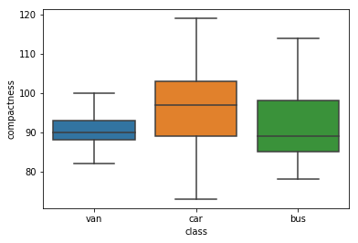

```python
sns.boxplot(x='class',y='compactness',data=data)
```

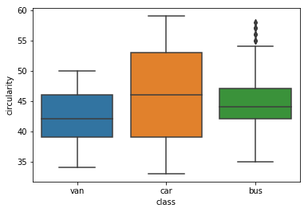

```python
sns.boxplot(x='class',y='circularity',data=data)
```

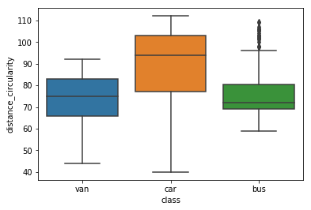

```python
sns.boxplot(x='class',y='distance_circularity',data=data)
```

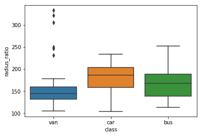

```python
sns.boxplot(x='class',y='radius_ratio',data=data)
```

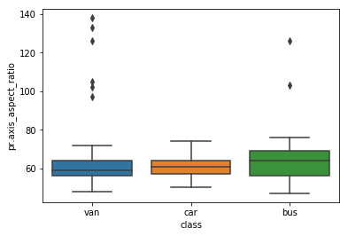

```python
sns.boxplot(x='class',y='pr.axis_aspect_ratio',data=data)
```

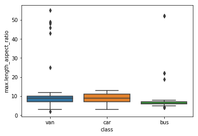

```python
sns.boxplot(x='class',y='max.length_aspect_ratio',data=data)
```

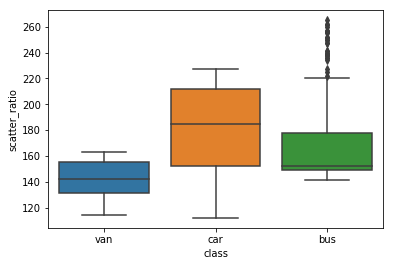

```python
sns.boxplot(x='class',y='scatter_ratio',data=data)
```

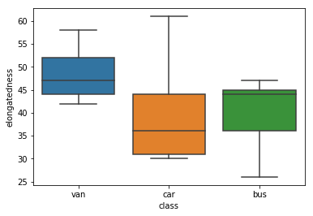

```python
sns.boxplot(x='class',y='elongatedness',data=data)
```

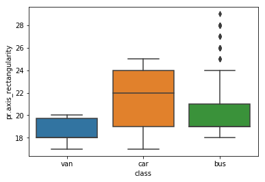

```python
sns.boxplot(x='class',y='pr.axis_rectangularity',data=data)
```

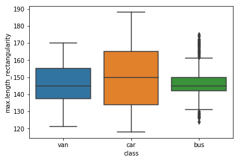

```python
sns.boxplot(x='class',y='max.length_rectangularity',data=data)
```

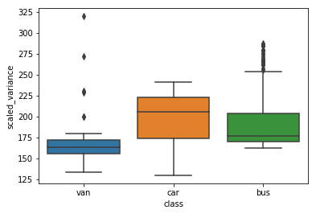

```python
sns.boxplot(x='class',y='scaled_variance',data=data)
```

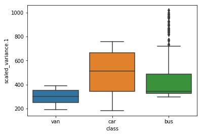

```python
sns.boxplot(x='class',y='scaled_variance.1',data=data)
```

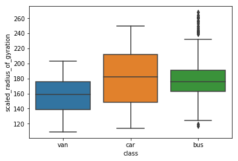

```python
sns.boxplot(x='class',y='scaled_radius_of_gyration',data=data)
```

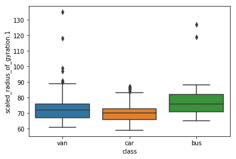

```python
sns.boxplot(x='class',y='scaled_radius_of_gyration.1',data=data)
```

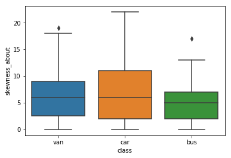

```python
sns.boxplot(x='class',y='skewness_about',data=data)
```

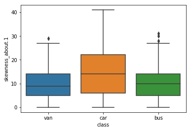

```python
sns.boxplot(x='class',y='skewness_about.1',data=data)
```

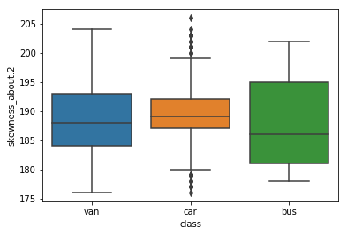

```python
sns.boxplot(x='class',y='skewness_about.2',data=data)
```

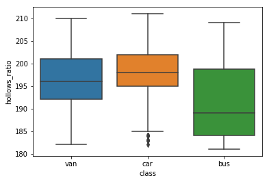

```python
sns.boxplot(x='class',y='hollows_ratio',data=data)
```

**Since there are outliers detected for most of the variables for vehicle type Van and Bus, we will do some outlier treatment by replacing missing values with Median and also dropping some variables which may not be relevant**

**Replace the missing/NaN with Median values**

```python
# for whole dataframe
from pandas.api.types import is_numeric_dtype
for name in list(data.columns):
    if is_numeric_dtype(data[name]):
        median = data.loc[:,name].median(axis=0,skipna = True)

        data[name].fillna(median, inplace=True)
data.head(100)
```

|  | compactness | circularity | distance_circularity | radius_ratio | pr.axis_aspect_ratio | max.length_aspect_ratio | scatter_ratio | elongatedness | pr.axis_rectangularity | max.length_rectangularity | scaled_variance | scaled_variance.1 | scaled_radius_of_gyration | scaled_radius_of_gyration.1 | skewness_about | skewness_about.1 | skewness_about.2 | hollows_ratio | class | vehicle |
| --- | --- | --- | --- | --- | --- | --- | --- | --- | --- | --- | --- | --- | --- | --- | --- | --- | --- | --- | --- | --- |
| 0 | 95 | 48.0 | 83.0 | 178.0 | 72.0 | 10 | 162.0 | 42.0 | 20.0 | 159 | 176.0 | 379.0 | 184.0 | 70.0 | 6.0 | 16.0 | 187.0 | 197 | van | 0.0 |
| 1 | 91 | 41.0 | 84.0 | 141.0 | 57.0 | 9 | 149.0 | 45.0 | 19.0 | 143 | 170.0 | 330.0 | 158.0 | 72.0 | 9.0 | 14.0 | 189.0 | 199 | van | 0.0 |
| 2 | 104 | 50.0 | 106.0 | 209.0 | 66.0 | 10 | 207.0 | 32.0 | 23.0 | 158 | 223.0 | 635.0 | 220.0 | 73.0 | 14.0 | 9.0 | 188.0 | 196 | car | 1.0 |
| 3 | 93 | 41.0 | 82.0 | 159.0 | 63.0 | 9 | 144.0 | 46.0 | 19.0 | 143 | 160.0 | 309.0 | 127.0 | 63.0 | 6.0 | 10.0 | 199.0 | 207 | van | 0.0 |
| 4 | 85 | 44.0 | 70.0 | 205.0 | 103.0 | 52 | 149.0 | 45.0 | 19.0 | 144 | 241.0 | 325.0 | 188.0 | 127.0 | 9.0 | 11.0 | 180.0 | 183 | bus | 2.0 |
| 5 | 107 | 44.0 | 106.0 | 172.0 | 50.0 | 6 | 255.0 | 26.0 | 28.0 | 169 | 280.0 | 957.0 | 264.0 | 85.0 | 5.0 | 9.0 | 181.0 | 183 | bus | 2.0 |
| 6 | 97 | 43.0 | 73.0 | 173.0 | 65.0 | 6 | 153.0 | 42.0 | 19.0 | 143 | 176.0 | 361.0 | 172.0 | 66.0 | 13.0 | 1.0 | 200.0 | 204 | bus | 2.0 |
| 7 | 90 | 43.0 | 66.0 | 157.0 | 65.0 | 9 | 137.0 | 48.0 | 18.0 | 146 | 162.0 | 281.0 | 164.0 | 67.0 | 3.0 | 3.0 | 193.0 | 202 | van | 0.0 |
| 8 | 86 | 34.0 | 62.0 | 140.0 | 61.0 | 7 | 122.0 | 54.0 | 17.0 | 127 | 141.0 | 223.0 | 112.0 | 64.0 | 2.0 | 14.0 | 200.0 | 208 | van | 0.0 |
| 9 | 93 | 44.0 | 98.0 | 167.0 | 62.0 | 11 | 183.0 | 36.0 | 22.0 | 146 | 202.0 | 505.0 | 152.0 | 64.0 | 4.0 | 14.0 | 195.0 | 204 | car | 1.0 |
| 10 | 86 | 36.0 | 70.0 | 143.0 | 61.0 | 9 | 133.0 | 50.0 | 18.0 | 130 | 153.0 | 266.0 | 127.0 | 66.0 | 2.0 | 10.0 | 194.0 | 202 | van | 0.0 |
| 11 | 90 | 34.0 | 66.0 | 136.0 | 55.0 | 6 | 123.0 | 54.0 | 17.0 | 118 | 148.0 | 224.0 | 118.0 | 65.0 | 5.0 | 26.0 | 196.0 | 202 | car | 1.0 |
| 12 | 88 | 46.0 | 74.0 | 171.0 | 68.0 | 6 | 152.0 | 43.0 | 19.0 | 148 | 180.0 | 349.0 | 192.0 | 71.0 | 5.0 | 11.0 | 189.0 | 195 | bus | 2.0 |
| 13 | 89 | 42.0 | 85.0 | 144.0 | 58.0 | 10 | 152.0 | 44.0 | 19.0 | 144 | 173.0 | 345.0 | 161.0 | 72.0 | 8.0 | 13.0 | 187.0 | 197 | van | 0.0 |
| 14 | 94 | 49.0 | 79.0 | 203.0 | 71.0 | 5 | 174.0 | 37.0 | 21.0 | 154 | 196.0 | 465.0 | 206.0 | 71.0 | 6.0 | 2.0 | 197.0 | 199 | bus | 2.0 |
| 15 | 96 | 55.0 | 103.0 | 201.0 | 65.0 | 9 | 204.0 | 32.0 | 23.0 | 166 | 227.0 | 624.0 | 246.0 | 74.0 | 6.0 | 2.0 | 186.0 | 194 | car | 1.0 |
| 16 | 89 | 36.0 | 51.0 | 109.0 | 52.0 | 6 | 118.0 | 57.0 | 17.0 | 129 | 137.0 | 206.0 | 125.0 | 80.0 | 2.0 | 14.0 | 181.0 | 185 | van | 0.0 |
| 17 | 99 | 41.0 | 77.0 | 197.0 | 69.0 | 6 | 177.0 | 36.0 | 21.0 | 139 | 202.0 | 485.0 | 151.0 | 72.0 | 4.0 | 10.0 | 198.0 | 199 | bus | 2.0 |
| 18 | 104 | 54.0 | 100.0 | 186.0 | 61.0 | 10 | 216.0 | 31.0 | 24.0 | 173 | 225.0 | 686.0 | 220.0 | 74.0 | 5.0 | 11.0 | 185.0 | 195 | car | 1.0 |
| 19 | 101 | 56.0 | 100.0 | 215.0 | 61.0 | 10 | 208.0 | 32.0 | 24.0 | 169 | 227.0 | 651.0 | 223.0 | 74.0 | 6.0 | 5.0 | 186.0 | 193 | car | 1.0 |
| 20 | 84 | 47.0 | 75.0 | 153.0 | 64.0 | 6 | 154.0 | 43.0 | 19.0 | 145 | 175.0 | 354.0 | 184.0 | 75.0 | 0.0 | 3.0 | 185.0 | 192 | bus | 2.0 |
| 21 | 84 | 37.0 | 53.0 | 121.0 | 59.0 | 5 | 123.0 | 55.0 | 17.0 | 125 | 141.0 | 221.0 | 133.0 | 82.0 | 7.0 | 1.0 | 179.0 | 183 | van | 0.0 |
| 22 | 94 | 43.0 | 64.0 | 173.0 | 69.0 | 7 | 150.0 | 43.0 | 19.0 | 142 | 169.0 | 344.0 | 177.0 | 68.0 | 9.0 | 1.0 | 199.0 | 206 | bus | 2.0 |
| 23 | 87 | 39.0 | 70.0 | 148.0 | 61.0 | 7 | 143.0 | 46.0 | 18.0 | 136 | 164.0 | 307.0 | 141.0 | 69.0 | 1.0 | 2.0 | 192.0 | 199 | bus | 2.0 |
| 24 | 99 | 53.0 | 105.0 | 219.0 | 66.0 | 11 | 204.0 | 32.0 | 23.0 | 165 | 221.0 | 623.0 | 224.0 | 68.0 | 0.0 | 6.0 | 191.0 | 201 | car | 1.0 |
| 25 | 85 | 45.0 | 80.0 | 154.0 | 64.0 | 9 | 147.0 | 45.0 | 19.0 | 148 | 169.0 | 324.0 | 174.0 | 71.0 | 1.0 | 4.0 | 188.0 | 199 | van | 0.0 |
| 26 | 83 | 36.0 | 54.0 | 119.0 | 57.0 | 6 | 128.0 | 53.0 | 18.0 | 125 | 143.0 | 238.0 | 139.0 | 82.0 | 6.0 | 3.0 | 179.0 | 183 | car | 1.0 |
| 27 | 107 | 54.0 | 98.0 | 203.0 | 65.0 | 11 | 218.0 | 31.0 | 25.0 | 167 | 229.0 | 696.0 | 216.0 | 72.0 | 1.0 | 28.0 | 187.0 | 199 | car | 1.0 |
| 28 | 102 | 45.0 | 85.0 | 193.0 | 64.0 | 6 | 192.0 | 33.0 | 22.0 | 146 | 217.0 | 570.0 | 163.0 | 76.0 | 6.0 | 7.0 | 195.0 | 193 | bus | 2.0 |
| 29 | 80 | 38.0 | 63.0 | 129.0 | 55.0 | 7 | 146.0 | 46.0 | 19.0 | 130 | 168.0 | 314.0 | 158.0 | 83.0 | 9.0 | 20.0 | 180.0 | 185 | car | 1.0 |
| ... | ... | ... | ... | ... | ... | ... | ... | ... | ... | ... | ... | ... | ... | ... | ... | ... | ... | ... | ... | ... |
| 70 | 96 | 55.0 | 98.0 | 161.0 | 54.0 | 10 | 215.0 | 31.0 | 20.0 | 175 | 226.0 | 683.0 | 221.0 | 76.0 | 3.0 | 6.0 | 185.0 | 193 | car | 1.0 |
| 71 | 97 | 59.0 | 108.0 | 227.0 | 70.0 | 11 | 224.0 | 30.0 | 25.0 | 186 | 225.0 | 732.0 | 218.0 | 70.0 | 10.0 | 25.0 | 186.0 | 198 | car | 1.0 |
| 72 | 92 | 39.0 | 91.0 | 191.0 | 62.0 | 8 | 176.0 | 37.0 | 21.0 | 137 | 196.0 | 466.0 | 151.0 | 67.0 | 3.0 | 23.0 | 192.0 | 200 | car | 1.0 |
| 73 | 73 | 37.0 | 53.0 | 111.0 | 54.0 | 6 | 126.0 | 55.0 | 18.0 | 128 | 135.0 | 227.0 | 147.0 | 82.0 | 1.0 | 15.0 | 176.0 | 184 | car | 1.0 |
| 74 | 89 | 42.0 | 89.0 | 147.0 | 61.0 | 11 | 151.0 | 44.0 | 19.0 | 145 | 170.0 | 338.0 | 163.0 | 72.0 | 11.0 | 23.0 | 187.0 | 199 | van | 0.0 |
| 75 | 101 | 53.0 | 103.0 | 203.0 | 63.0 | 9 | 195.0 | 34.0 | 22.0 | 162 | 210.0 | 571.0 | 210.0 | 68.0 | 5.0 | 5.0 | 191.0 | 198 | car | 1.0 |
| 76 | 91 | 39.0 | 83.0 | 170.0 | 60.0 | 8 | 172.0 | 38.0 | 21.0 | 134 | 197.0 | 445.0 | 152.0 | 72.0 | 0.0 | 10.0 | 188.0 | 194 | car | 1.0 |
| 77 | 86 | 40.0 | 62.0 | 140.0 | 62.0 | 7 | 150.0 | 45.0 | 19.0 | 133 | 165.0 | 330.0 | 173.0 | 71.5 | 2.0 | 3.0 | 180.0 | 185 | car | 1.0 |
| 78 | 104 | 52.0 | 94.0 | 167.0 | 66.0 | 5 | 208.0 | 31.0 | 24.0 | 161 | 227.0 | 666.0 | 218.0 | 76.0 | 11.0 | 4.0 | 193.0 | 191 | bus | 2.0 |
| 79 | 89 | 44.0 | 68.0 | 113.0 | 50.0 | 7 | 150.0 | 45.0 | 19.0 | 147 | 171.0 | 328.0 | 189.0 | 88.0 | 6.0 | 5.0 | 179.0 | 182 | bus | 2.0 |
| 80 | 87 | 46.0 | 71.0 | 159.0 | 66.0 | 6 | 151.0 | 44.0 | 19.0 | 146 | 175.0 | 343.0 | 189.0 | 73.0 | 2.0 | 0.0 | 186.0 | 190 | bus | 2.0 |
| 81 | 99 | 51.0 | 92.0 | 203.0 | 65.0 | 5 | 209.0 | 31.0 | 24.0 | 159 | 232.0 | 671.0 | 214.0 | 78.0 | 5.0 | 11.0 | 191.0 | 189 | bus | 2.0 |
| 82 | 94 | 36.0 | 68.0 | 127.0 | 54.0 | 7 | 127.0 | 52.0 | 18.0 | 132 | 155.0 | 242.0 | 116.0 | 66.0 | 1.0 | 2.0 | 195.0 | 196 | van | 0.0 |
| 83 | 79 | 40.0 | 80.0 | 133.0 | 55.0 | 7 | 147.0 | 47.0 | 19.0 | 135 | 172.0 | 311.0 | 144.0 | 76.0 | 8.0 | 30.0 | 181.0 | 193 | car | 1.0 |
| 84 | 89 | 40.0 | 76.0 | 188.0 | 76.0 | 7 | 150.0 | 44.0 | 19.0 | 136 | 174.0 | 342.0 | 148.0 | 72.0 | 3.0 | 8.0 | 193.0 | 197 | bus | 2.0 |
| 85 | 110 | 58.0 | 106.0 | 180.0 | 51.0 | 6 | 261.0 | 26.0 | 28.0 | 171 | 278.0 | 998.0 | 257.0 | 83.0 | 9.0 | 13.0 | 181.0 | 182 | bus | 2.0 |
| 86 | 89 | 41.0 | 84.0 | 141.0 | 58.0 | 9 | 149.0 | 45.0 | 19.0 | 145 | 172.0 | 330.0 | 162.0 | 72.0 | 4.0 | 18.0 | 188.0 | 200 | van | 0.0 |
| 87 | 86 | 37.0 | 60.0 | 115.0 | 54.0 | 5 | 119.0 | 56.0 | 17.0 | 132 | 141.0 | 209.0 | 129.0 | 72.0 | 2.0 | 8.0 | 186.0 | 190 | van | 0.0 |
| 88 | 91 | 42.0 | 84.0 | 209.0 | 75.0 | 6 | 171.0 | 38.0 | 20.0 | 138 | 189.0 | 446.0 | 161.0 | 69.0 | 3.0 | 12.0 | 196.0 | 201 | bus | 2.0 |
| 89 | 80 | 37.0 | 57.0 | 116.0 | 55.0 | 6 | 125.0 | 54.0 | 18.0 | 125 | 142.0 | 229.0 | 132.0 | 81.0 | 8.0 | 5.0 | 178.0 | 184 | car | 1.0 |
| 90 | 104 | 55.0 | 107.0 | 222.0 | 68.0 | 11 | 218.0 | 31.0 | 24.0 | 173 | 232.0 | 703.0 | 229.0 | 71.0 | 3.0 | 10.0 | 188.0 | 199 | car | 1.0 |
| 91 | 94 | 38.0 | 84.0 | 158.0 | 55.0 | 9 | 169.0 | 39.0 | 20.0 | 130 | 196.0 | 430.0 | 155.0 | 69.0 | 9.0 | 15.0 | 190.0 | 195 | car | 1.0 |
| 92 | 104 | 52.0 | 100.0 | 191.0 | 59.0 | 9 | 197.0 | 33.0 | 23.0 | 158 | 218.0 | 583.0 | 234.0 | 70.0 | 10.0 | 10.0 | 191.0 | 198 | car | 1.0 |
| 93 | 94 | 48.0 | 87.0 | 162.0 | 64.0 | 10 | 157.0 | 43.0 | 20.0 | 161 | 179.0 | 363.0 | 186.0 | 75.0 | 4.0 | 15.0 | 184.0 | 195 | van | 0.0 |
| 94 | 84 | 45.0 | 66.0 | 154.0 | 65.0 | 6 | 145.0 | 46.0 | 19.0 | 144 | 168.0 | 312.0 | 177.0 | 73.0 | 2.0 | 3.0 | 184.0 | 188 | bus | 2.0 |
| 95 | 97 | 50.0 | 108.0 | 211.0 | 65.0 | 10 | 214.0 | 31.0 | 24.0 | 156 | 232.0 | 683.0 | 218.0 | 72.0 | 7.0 | 29.0 | 188.0 | 197 | car | 1.0 |
| 96 | 89 | 42.0 | 80.0 | 151.0 | 62.0 | 6 | 144.0 | 46.0 | 19.0 | 139 | 166.0 | 308.0 | 170.0 | 74.0 | 17.0 | 13.0 | 185.0 | 189 | car | 1.0 |
| 97 | 86 | 43.0 | 68.0 | 152.0 | 62.0 | 7 | 150.0 | 44.0 | 19.0 | 142 | 179.0 | 337.0 | 164.0 | 75.0 | 4.0 | 9.0 | 188.0 | 192 | bus | 2.0 |
| 98 | 95 | 46.0 | 105.0 | 219.0 | 68.0 | 9 | 201.0 | 33.0 | 23.0 | 148 | 223.0 | 602.0 | 201.0 | 69.0 | 5.0 | 38.0 | 191.0 | 202 | car | 1.0 |
| 99 | 87 | 44.0 | 65.0 | 124.0 | 56.0 | 6 | 149.0 | 46.0 | 19.0 | 144 | 170.0 | 321.0 | 171.0 | 87.0 | 4.0 | 12.0 | 179.0 | 182 | bus | 2.0 |

100 rows × 20 columns

```python
data.describe().transpose()
```

|  | count | mean | std | min | 25% | 50% | 75% | max |
| --- | --- | --- | --- | --- | --- | --- | --- | --- |
| compactness | 846.0 | 93.678487 | 8.234474 | 73.0 | 87.00 | 93.0 | 100.00 | 119.0 |
| circularity | 846.0 | 44.823877 | 6.134272 | 33.0 | 40.00 | 44.0 | 49.00 | 59.0 |
| distance_circularity | 846.0 | 82.100473 | 15.741569 | 40.0 | 70.00 | 80.0 | 98.00 | 112.0 |
| radius_ratio | 846.0 | 168.874704 | 33.401356 | 104.0 | 141.00 | 167.0 | 195.00 | 333.0 |
| pr.axis_aspect_ratio | 846.0 | 61.677305 | 7.882188 | 47.0 | 57.00 | 61.0 | 65.00 | 138.0 |
| max.length_aspect_ratio | 846.0 | 8.567376 | 4.601217 | 2.0 | 7.00 | 8.0 | 10.00 | 55.0 |
| scatter_ratio | 846.0 | 168.887707 | 33.197710 | 112.0 | 147.00 | 157.0 | 198.00 | 265.0 |
| elongatedness | 846.0 | 40.936170 | 7.811882 | 26.0 | 33.00 | 43.0 | 46.00 | 61.0 |
| pr.axis_rectangularity | 846.0 | 20.580378 | 2.588558 | 17.0 | 19.00 | 20.0 | 23.00 | 29.0 |
| max.length_rectangularity | 846.0 | 147.998818 | 14.515652 | 118.0 | 137.00 | 146.0 | 159.00 | 188.0 |
| scaled_variance | 846.0 | 188.596927 | 31.360427 | 130.0 | 167.00 | 179.0 | 217.00 | 320.0 |
| scaled_variance.1 | 846.0 | 439.314421 | 176.496341 | 184.0 | 318.25 | 363.5 | 586.75 | 1018.0 |
| scaled_radius_of_gyration | 846.0 | 174.706856 | 32.546277 | 109.0 | 149.00 | 173.5 | 198.00 | 268.0 |
| scaled_radius_of_gyration.1 | 846.0 | 72.443262 | 7.468734 | 59.0 | 67.00 | 71.5 | 75.00 | 135.0 |
| skewness_about | 846.0 | 6.361702 | 4.903244 | 0.0 | 2.00 | 6.0 | 9.00 | 22.0 |
| skewness_about.1 | 846.0 | 12.600473 | 8.930962 | 0.0 | 5.00 | 11.0 | 19.00 | 41.0 |
| skewness_about.2 | 846.0 | 188.918440 | 6.152247 | 176.0 | 184.00 | 188.0 | 193.00 | 206.0 |
| hollows_ratio | 846.0 | 195.632388 | 7.438797 | 181.0 | 190.25 | 197.0 | 201.00 | 211.0 |
| vehicle | 846.0 | 1.022459 | 0.702130 | 0.0 | 1.00 | 1.0 | 2.00 | 2.0 |

**Finding unique data**

```python
data.apply(lambda x: len(x.unique()))
```

```
compactness                     44
circularity                     27
distance_circularity            63
radius_ratio                   134
pr.axis_aspect_ratio            37
max.length_aspect_ratio         21
scatter_ratio                  131
elongatedness                   35
pr.axis_rectangularity          13
max.length_rectangularity       66
scaled_variance                128
scaled_variance.1              423
scaled_radius_of_gyration      144
scaled_radius_of_gyration.1     40
skewness_about                  23
skewness_about.1                41
skewness_about.2                30
hollows_ratio                   31
class                            3
vehicle                          3
dtype: int64
```

**Split the data into groups based on size and count**

```python
data.groupby(by='class').size()
```

```
class
bus    218
car    429
van    199
dtype: int64
```

```python
data.groupby(by='class').count()
```

| class | compactness | circularity | distance_circularity | radius_ratio | pr.axis_aspect_ratio | max.length_aspect_ratio | scatter_ratio | elongatedness | pr.axis_rectangularity | max.length_rectangularity | scaled_variance | scaled_variance.1 | scaled_radius_of_gyration | scaled_radius_of_gyration.1 | skewness_about | skewness_about.1 | skewness_about.2 | hollows_ratio | vehicle |
| --- | --- | --- | --- | --- | --- | --- | --- | --- | --- | --- | --- | --- | --- | --- | --- | --- | --- | --- | --- |
| bus | 218 | 218 | 218 | 218 | 218 | 218 | 218 | 218 | 218 | 218 | 218 | 218 | 218 | 218 | 218 | 218 | 218 | 218 | 218 |
| car | 429 | 429 | 429 | 429 | 429 | 429 | 429 | 429 | 429 | 429 | 429 | 429 | 429 | 429 | 429 | 429 | 429 | 429 | 429 |
| van | 199 | 199 | 199 | 199 | 199 | 199 | 199 | 199 | 199 | 199 | 199 | 199 | 199 | 199 | 199 | 199 | 199 | 199 | 199 |

```
array([[<matplotlib.axes._subplots.AxesSubplot object at 0x0000013FBBD99F98>,
      dtype=object)
```

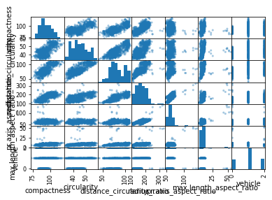

```python
from pandas.plotting import scatter_matrix
params=['compactness','circularity','distance_circularity','radius_ratio','pr.axis_aspect_ratio','max.length_aspect_ratio','vehicle']

scatter_matrix(data[params], alpha=0.4)
```

```
array([[<matplotlib.axes._subplots.AxesSubplot object at 0x0000013FBD8B7748>,
      dtype=object)
```

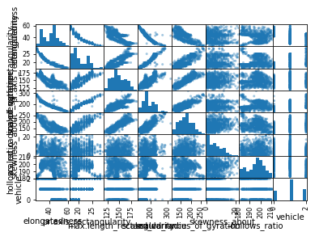

```python
from pandas.plotting import scatter_matrix
params=['elongatedness','pr.axis_rectangularity','max.length_rectangularity','scaled_variance','scaled_radius_of_gyration','skewness_about','hollows_ratio','vehicle']

scatter_matrix(data[params], alpha=0.4)
```

```python
import scipy.stats as stats
pd.DataFrame([stats.skew(data['compactness']),stats.skew(data['max.length_aspect_ratio']),stats.skew(data['circularity']),stats.skew(data['max.length_rectangularity']),stats.skew(data['distance_circularity']),stats.skew(data['hollows_ratio']),stats.skew(data['elongatedness']),stats.skew(data['radius_ratio']),stats.skew(data['scatter_ratio']),stats.skew(data['pr.axis_rectangularity']),stats.skew(data['max.length_rectangularity']),stats.skew(data['scaled_variance']),stats.skew(data['scaled_variance.1']),stats.skew(data['scaled_radius_of_gyration']),stats.skew(data['scaled_radius_of_gyration.1']),stats.skew(data['skewness_about']),stats.skew(data['skewness_about.1']),stats.skew(data['skewness_about.2'])],index=['compactness','max.length_aspect_ratio','circularity','max.length_rectangularity','distance_circularity','hollows_ratio','elongatedness','radius_ratio','scatter_ratio','pr.axis_rectangularity','max.length_rectangularity','scaled_variance','scaled_variance.1','scaled_radius_of_gyration','scaled_radius_of_gyration.1','skewness_about','skewness_about.1','skewness_about.2'],columns=['skewness'])
```

|  | skewness |
| --- | --- |
| compactness | 0.380594 |
| max.length_aspect_ratio | 6.766369 |
| circularity | 0.264458 |
| max.length_rectangularity | 0.255904 |
| distance_circularity | 0.108525 |
| hollows_ratio | -0.225940 |
| elongatedness | 0.046868 |
| radius_ratio | 0.396866 |
| scatter_ratio | 0.607630 |
| pr.axis_rectangularity | 0.773032 |
| max.length_rectangularity | 0.255904 |
| scaled_variance | 0.654435 |
| scaled_variance.1 | 0.843846 |
| scaled_radius_of_gyration | 0.279413 |
| scaled_radius_of_gyration.1 | 2.086271 |
| skewness_about | 0.779428 |
| skewness_about.1 | 0.687792 |
| skewness_about.2 | 0.249542 |

**Check the Correlation**

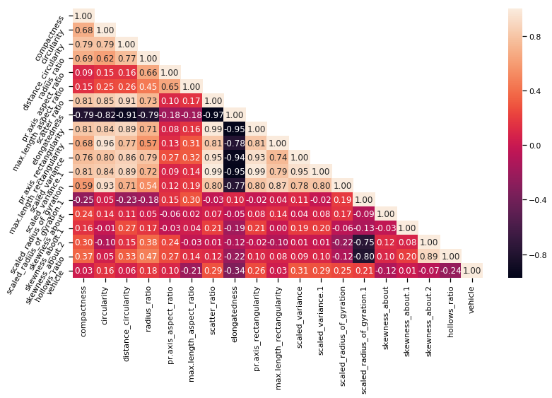

```python
corr=data.corr()
sns.set_context("notebook", font_scale=1.0, rc={"lines.linewidth": 2.5})
plt.figure(figsize=(13,7))
# create a mask so we only see the correlation values once
mask = np.zeros_like(corr)
mask[np.triu_indices_from(mask, 1)] = True
a = sns.heatmap(corr,mask=mask, annot=True, fmt='.2f')
rotx = a.set_xticklabels(a.get_xticklabels(), rotation=90)
roty = a.set_yticklabels(a.get_yticklabels(), rotation=60)
```

**Correlation Inference :**

From the correlation co-efficient,

**elongatedness seem to be having a good negative correlation with compactness, circularity, distance_circularity, radius_ratio, scatter_ratio**

**scaled_radius_of_gyration seems to be having a very good positive correlation with circularity,scatter_ratio,pr.axis_rectangularity,max.length_rectangularity,scaled_variance.1**

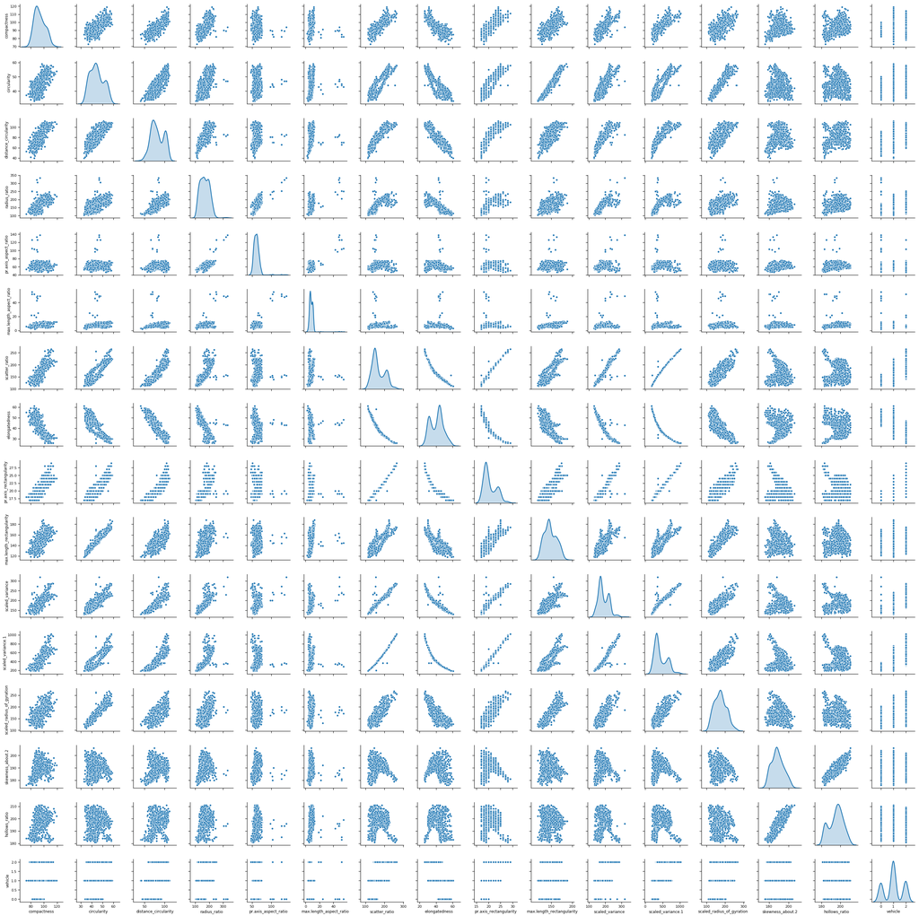

```python
# independant variables
X = data.drop(['scaled_radius_of_gyration.1','skewness_about','skewness_about.1','class'], axis=1)
# the dependent variable
y = data[['vehicle']]

sns.pairplot(X, diag_kind='kde')   # to plot density curve instead of histogram on the diag
```

```python
from scipy.stats import zscore
XScaled=X.apply(zscore)
XScaled.head()
```

|  | compactness | circularity | distance_circularity | radius_ratio | pr.axis_aspect_ratio | max.length_aspect_ratio | scatter_ratio | elongatedness | pr.axis_rectangularity | max.length_rectangularity | scaled_variance | scaled_variance.1 | scaled_radius_of_gyration | skewness_about.2 | hollows_ratio | vehicle |
| --- | --- | --- | --- | --- | --- | --- | --- | --- | --- | --- | --- | --- | --- | --- | --- | --- |
| 0 | 0.160580 | 0.518073 | 0.057177 | 0.273363 | 1.310398 | 0.311542 | -0.207598 | 0.136262 | -0.224342 | 0.758332 | -0.401920 | -0.341934 | 0.285705 | -0.312012 | 0.183957 | -1.457086 |
| 1 | -0.325470 | -0.623732 | 0.120741 | -0.835032 | -0.593753 | 0.094079 | -0.599423 | 0.520519 | -0.610886 | -0.344578 | -0.593357 | -0.619724 | -0.513630 | 0.013265 | 0.452977 | -1.457086 |
| 2 | 1.254193 | 0.844303 | 1.519141 | 1.202018 | 0.548738 | 0.311542 | 1.148719 | -1.144597 | 0.935290 | 0.689401 | 1.097671 | 1.109379 | 1.392477 | -0.149374 | 0.049447 | -0.032005 |
| 3 | -0.082445 | -0.623732 | -0.006386 | -0.295813 | 0.167907 | 0.094079 | -0.750125 | 0.648605 | -0.610886 | -0.344578 | -0.912419 | -0.738777 | -1.466683 | 1.639649 | 1.529056 | -1.457086 |
| 4 | -1.054545 | -0.134387 | -0.769150 | 1.082192 | 5.245643 | 9.444962 | -0.599423 | 0.520519 | -0.610886 | -0.275646 | 1.671982 | -0.648070 | 0.408680 | -1.450481 | -1.699181 | 1.393075 |

```python
covMatrix = np.cov(XScaled,rowvar=False)
print(covMatrix)
```

```
[[ 1.00118343  0.68569786  0.79086299  0.69055952  0.09164265  0.14842463
   0.81358214 -0.78968322  0.81465658  0.67694334  0.76297234  0.81497566
   0.58593517  0.29889034  0.36598446  0.03383559]
 [ 0.68569786  1.00118343  0.79325751  0.6216467   0.15396023  0.25176438
   0.8489411  -0.82244387  0.84439802  0.96245572  0.79724837  0.83693508
   0.92691166 -0.10455005  0.04640562  0.15909793]
 [ 0.79086299  0.79325751  1.00118343  0.76794246  0.15864319  0.26499957
   0.90614687 -0.9123854   0.89408198  0.77544391  0.86253904  0.88706577
   0.70660663  0.14627113  0.33312625  0.06454368]
 [ 0.69055952  0.6216467   0.76794246  1.00118343  0.66423242  0.45058426
   0.73529816 -0.79041561  0.70922371  0.56962256  0.79435372  0.71928618
   0.53700678  0.38266622  0.47186659  0.18240153]
 [ 0.09164265  0.15396023  0.15864319  0.66423242  1.00118343  0.64949139
   0.10385472 -0.18325156  0.07969786  0.1270594   0.27323306  0.08929427
   0.12211524  0.24016968  0.26804208  0.0982946 ]
 [ 0.14842463  0.25176438  0.26499957  0.45058426  0.64949139  1.00118343
   0.16638787 -0.18035326  0.16169312  0.30630475  0.31933428  0.1434227
   0.18996732 -0.02611148  0.14408905 -0.20786508]
 [ 0.81358214  0.8489411   0.90614687  0.73529816  0.10385472  0.16638787
   1.00118343 -0.97275069  0.99092181  0.81004084  0.94978498  0.9941867
   0.80082111  0.00563439  0.1189581   0.28923705]
 [-0.78968322 -0.82244387 -0.9123854  -0.79041561 -0.18325156 -0.18035326
  -0.97275069  1.00118343 -0.95011894 -0.77677186 -0.93748998 -0.95494487
  -0.76722075 -0.11526213 -0.2171615  -0.33974562]
 [ 0.81465658  0.84439802  0.89408198  0.70922371  0.07969786  0.16169312
   0.99092181 -0.95011894  1.00118343  0.81189327  0.93533261  0.98938264
   0.79763248 -0.01867064  0.09940372  0.258787  ]
 [ 0.67694334  0.96245572  0.77544391  0.56962256  0.1270594   0.30630475
   0.81004084 -0.77677186  0.81189327  1.00118343  0.74586628  0.79555492
   0.86747579 -0.10407076  0.07686047  0.03243711]
 [ 0.76297234  0.79724837  0.86253904  0.79435372  0.27323306  0.31933428
   0.94978498 -0.93748998  0.93533261  0.74586628  1.00118343  0.94679667
   0.77983844  0.01423606  0.08579656  0.31331337]
 [ 0.81497566  0.83693508  0.88706577  0.71928618  0.08929427  0.1434227
   0.9941867  -0.95494487  0.98938264  0.79555492  0.94679667  1.00118343
   0.79595778  0.00622636  0.10305714  0.288456  ]
 [ 0.58593517  0.92691166  0.70660663  0.53700678  0.12211524  0.18996732
   0.80082111 -0.76722075  0.79763248  0.86747579  0.77983844  0.79595778
   1.00118343 -0.22471583 -0.11814142  0.25056269]
 [ 0.29889034 -0.10455005  0.14627113  0.38266622  0.24016968 -0.02611148
   0.00563439 -0.11526213 -0.01867064 -0.10407076  0.01423606  0.00622636
  -0.22471583  1.00118343  0.89363767 -0.06732393]
 [ 0.36598446  0.04640562  0.33312625  0.47186659  0.26804208  0.14408905
   0.1189581  -0.2171615   0.09940372  0.07686047  0.08579656  0.10305714
  -0.11814142  0.89363767  1.00118343 -0.23615329]
 [ 0.03383559  0.15909793  0.06454368  0.18240153  0.0982946  -0.20786508
   0.28923705 -0.33974562  0.258787    0.03243711  0.31331337  0.288456
   0.25056269 -0.06732393 -0.23615329  1.00118343]]
```

```python
from sklearn.decomposition import PCA
pca = PCA(n_components=10)
pca.fit(XScaled)
```

```
PCA(copy=True, iterated_power='auto', n_components=10, random_state=None,
  svd_solver='auto', tol=0.0, whiten=False)
```

**The eigen Values**

```python
print(pca.explained_variance_)
```

```
[9.40733325 2.50170256 1.57494115 1.18509857 0.48517722 0.26471275
 0.22830331 0.11081251 0.08860478 0.05493592]
```

**The eigen Vectors**

```python
print(pca.components_)
```

```
[[ 2.72498765e-01  2.94243585e-01  3.02155394e-01  2.66861986e-01
   8.17990744e-02  9.57322226e-02  3.17717568e-01 -3.15137130e-01
   3.14330850e-01  2.82663514e-01  3.10717945e-01  3.14510215e-01
   2.74504587e-01  2.57865312e-02  6.73984752e-02  7.62574192e-02]
 [ 1.08387628e-01 -1.20298579e-01  6.21849137e-02  2.90379704e-01
   3.54319624e-01  2.30205268e-01 -7.74854156e-02  8.67253273e-03
  -9.11414115e-02 -9.98294423e-02 -3.15921983e-02 -8.55692774e-02
  -2.09680755e-01  5.38488574e-01  5.53341174e-01 -1.85099201e-01]
 [-2.13917851e-01  7.13538300e-02 -8.22328464e-02  1.34429492e-01
   5.36016071e-01  6.21782492e-01 -8.73267333e-02  9.06255372e-02
  -8.87106432e-02  8.38112218e-02  5.35352538e-02 -9.99779970e-02
   1.05870428e-01 -3.46931896e-01 -2.69903029e-01 -4.87355834e-02]
 [-1.30782381e-01 -1.50695137e-01 -1.25903581e-01  1.82788938e-01
   2.88102062e-01 -1.76992150e-01  3.70181350e-02 -1.14644994e-01
   3.39970071e-03 -2.73231781e-01  1.15369954e-01  4.01914696e-02
  -6.05785590e-02  1.17213627e-01 -9.26459411e-02  8.16391934e-01]
 [ 1.90543793e-01 -4.49254461e-01  1.62229173e-01  6.22066470e-02
  -1.31717059e-01  2.25917733e-01  1.68958413e-01 -9.04667618e-02
   1.88382655e-01 -4.18335646e-01  2.53529581e-01  1.83544144e-01
  -4.51205865e-01 -2.14678478e-01 -1.93108531e-01 -1.76446052e-01]
 [-2.41029281e-01  1.71771803e-02  1.11932425e-01 -3.18818345e-01
  -4.54470618e-01  6.02977331e-01  2.41488115e-02 -9.53130421e-02
   4.16078134e-04  1.16297470e-01  4.94108068e-03 -2.36770889e-02
  -8.41894284e-02  9.60187185e-02  2.70092414e-01  3.79835781e-01]
 [ 7.61924332e-01  3.77004316e-02 -4.33021004e-01 -1.50284714e-01
  -4.72868217e-02  2.39370682e-01 -7.41918260e-02  1.88704581e-01
  -3.55718612e-02  7.58003395e-02  8.62101567e-03 -2.10859634e-02
   1.96230374e-02  1.75312035e-01 -1.96194033e-01  1.73688315e-01]
 [-1.74804569e-01 -1.37661736e-01 -1.00048313e-01 -4.26689859e-02
  -1.54401560e-01  1.04244610e-01 -4.44521448e-02  6.00626565e-02
  -6.31296097e-02 -3.98952808e-01  4.00344025e-01  4.11807889e-02
   6.34221935e-01  3.49353925e-01 -1.27107850e-01 -1.81135547e-01]
 [-3.61085870e-01  2.89174923e-02 -5.83149681e-01 -6.55341288e-02
   4.18374173e-02 -3.07461846e-02  1.78816225e-01 -2.66386427e-02
   2.39172431e-01  3.03289330e-01  2.12487989e-01  2.88498572e-01
  -3.14919169e-01  2.66451540e-01 -9.87863000e-02 -1.77601419e-01]
 [ 1.78624843e-02 -1.12863292e-01 -3.80449093e-01  3.89174223e-02
   1.24055837e-02  4.59945792e-02  1.57419233e-01  1.57007925e-01
   3.27901359e-01 -2.33408313e-01 -2.79090969e-01  2.30646975e-01
   2.84611786e-01 -3.90063641e-01  5.12232335e-01  1.90003240e-02]]
```

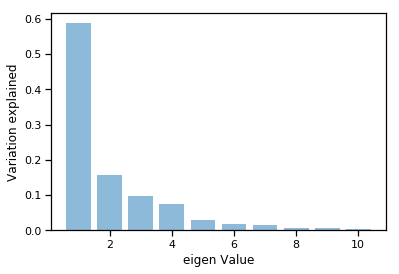

```python
plt.bar(list(range(1,11)),pca.explained_variance_ratio_,alpha=0.5, align='center')
plt.ylabel('Variation explained')
plt.xlabel('eigen Value')
plt.show()
```

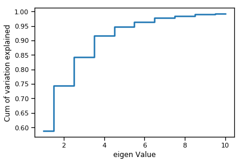

```python
plt.step(list(range(1,11)),np.cumsum(pca.explained_variance_ratio_), where='mid')
plt.ylabel('Cum of variation explained')
plt.xlabel('eigen Value')
plt.show()
```

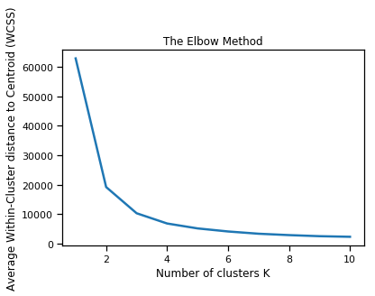

```python
X=data.iloc[: , [0,8]].values

# Using the elbow method to find  the optimal number of clusters
from sklearn.cluster import KMeans
wcss = []
for i in range(1, 11):
  kmeans=KMeans(n_clusters=i, init='k-means++', max_iter= 300, n_init= 10, random_state= 0)
  kmeans.fit(X)
  wcss.append(kmeans.inertia_)
plt.plot(range(1, 11),wcss)
plt.title('The Elbow Method')
plt.xlabel('Number of clusters K')
plt.ylabel('Average Within-Cluster distance to Centroid (WCSS)')
plt.show()

# Applying k-means to the  dataset
kmeans=KMeans(n_clusters=3, init='k-means++', max_iter= 300, n_init= 10, random_state= 0)
y_kmeans=kmeans.fit_predict(X)
```

**Dimensionality Reduction**

Now 7 dimensions seems very reasonable. With 7 variables we can explain over 95% of the variation in the original data!

```python
pca3 = PCA(n_components=7)
pca3.fit(XScaled)
print(pca3.components_)
print(pca3.explained_variance_ratio_)
Xpca3 = pca3.transform(XScaled)
```

```
[[ 2.72498765e-01  2.94243585e-01  3.02155394e-01  2.66861986e-01
   8.17990744e-02  9.57322226e-02  3.17717568e-01 -3.15137130e-01
   3.14330850e-01  2.82663514e-01  3.10717945e-01  3.14510215e-01
   2.74504587e-01  2.57865312e-02  6.73984752e-02  7.62574192e-02]
 [ 1.08387628e-01 -1.20298579e-01  6.21849137e-02  2.90379704e-01
   3.54319624e-01  2.30205268e-01 -7.74854156e-02  8.67253273e-03
  -9.11414115e-02 -9.98294423e-02 -3.15921983e-02 -8.55692774e-02
  -2.09680755e-01  5.38488574e-01  5.53341174e-01 -1.85099201e-01]
 [-2.13917851e-01  7.13538300e-02 -8.22328464e-02  1.34429492e-01
   5.36016071e-01  6.21782492e-01 -8.73267333e-02  9.06255372e-02
  -8.87106432e-02  8.38112218e-02  5.35352538e-02 -9.99779970e-02
   1.05870428e-01 -3.46931896e-01 -2.69903029e-01 -4.87355834e-02]
 [-1.30782381e-01 -1.50695137e-01 -1.25903581e-01  1.82788938e-01
   2.88102062e-01 -1.76992150e-01  3.70181350e-02 -1.14644994e-01
   3.39970071e-03 -2.73231781e-01  1.15369954e-01  4.01914696e-02
  -6.05785590e-02  1.17213627e-01 -9.26459411e-02  8.16391934e-01]
 [ 1.90543793e-01 -4.49254461e-01  1.62229173e-01  6.22066470e-02
  -1.31717059e-01  2.25917733e-01  1.68958413e-01 -9.04667618e-02
   1.88382655e-01 -4.18335646e-01  2.53529581e-01  1.83544144e-01
  -4.51205865e-01 -2.14678478e-01 -1.93108531e-01 -1.76446052e-01]
 [-2.41029281e-01  1.71771803e-02  1.11932425e-01 -3.18818345e-01
  -4.54470618e-01  6.02977331e-01  2.41488115e-02 -9.53130421e-02
   4.16078134e-04  1.16297470e-01  4.94108068e-03 -2.36770889e-02
  -8.41894284e-02  9.60187185e-02  2.70092414e-01  3.79835781e-01]
 [ 7.61924332e-01  3.77004316e-02 -4.33021004e-01 -1.50284714e-01
  -4.72868217e-02  2.39370682e-01 -7.41918260e-02  1.88704581e-01
  -3.55718612e-02  7.58003395e-02  8.62101567e-03 -2.10859634e-02
   1.96230374e-02  1.75312035e-01 -1.96194033e-01  1.73688315e-01]]
[0.58726334 0.15617159 0.09831747 0.07398111 0.03028773 0.01652499
 0.01425209]
```

```python
Xpca3
```

```
array([[ 0.19761598,  0.72157625,  1.21722809, ..., -0.69000418,
        -0.99981547, -0.13929091],
       [-1.74255044,  0.46407756, -0.31203208, ...,  0.30035265,
         0.19477727, -0.3511362 ],
       [ 3.72848782,  0.02229256,  0.22253146, ...,  0.24620844,
        -0.49633027, -0.11268974],
       ...,
       [ 4.88151197,  0.36436777,  0.35904061, ...,  0.1786531 ,
        -0.13592526,  0.0618351 ],
       [-3.34568083,  0.29996791, -0.37655543, ...,  0.50178298,
         0.13628094, -0.36703679],
       [-4.86168387, -0.45220319, -0.25989862, ...,  0.50496886,
        -0.57756877, -0.13573372]])
```

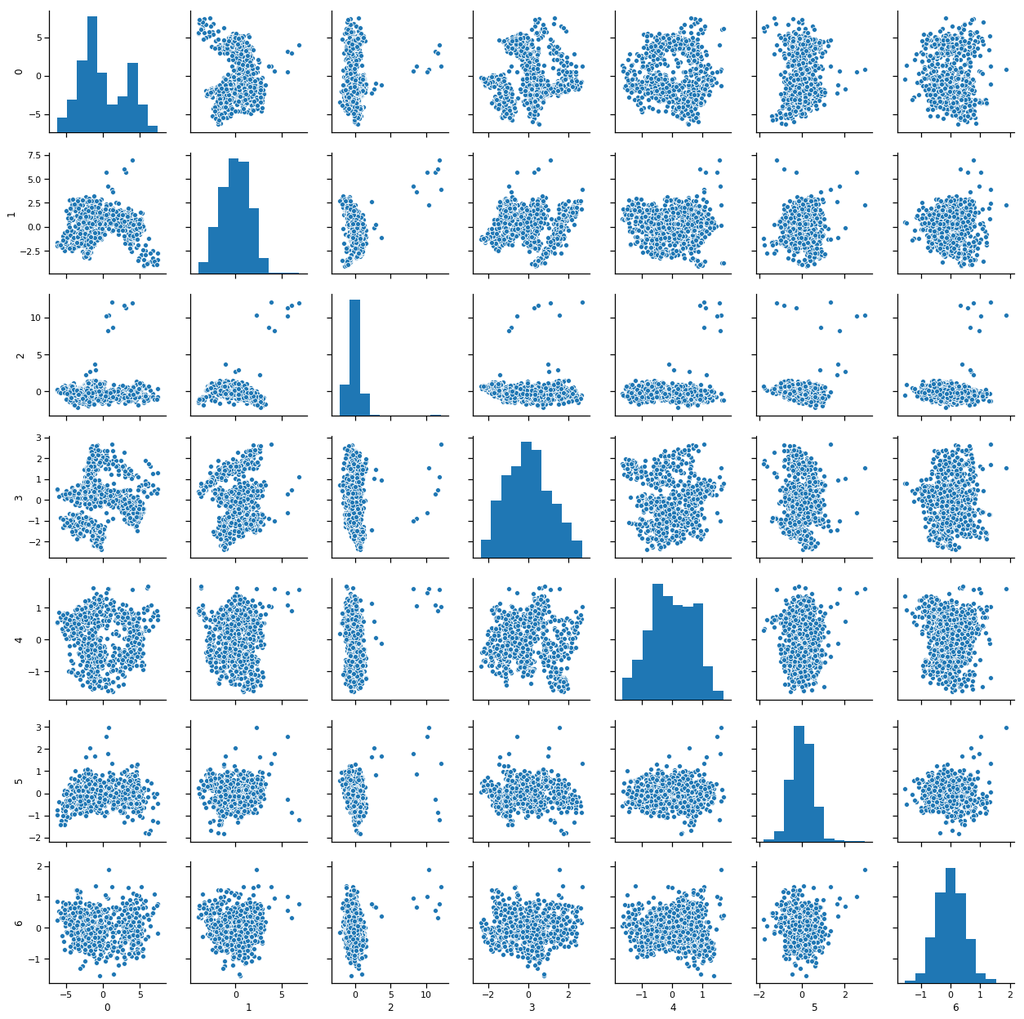

```python
sns.pairplot(pd.DataFrame(Xpca3))
```

**Linear Regression without PCA**

```python
from sklearn.linear_model import LinearRegression
regression_model = LinearRegression()
regression_model.fit(XScaled, y)
regression_model.score(XScaled, y)
```

```
1.0
```

**Linear Regression with PCA**

```python
regression_model_pca = LinearRegression()
regression_model_pca.fit(Xpca3, y)
regression_model_pca.score(Xpca3, y)
```

```
0.9930308247685727
```

**Inference**

Looks like by reducing dimensionality by 7, we only dropped around 1% in R^2! This is insample (on training data) and hence a drop in R^2 is expected. Still seems easy to justify the dropping of variables. An out of sample (on test data), with the 7 independent variables is likely to do better since that would be less of an over-fit.

**Let us proceed to try some nonlinear classifiers such as Support vector machines.**

```python
#Separate features and labels
X = data.iloc[:,0:8].values
y = data.iloc[:,8].values

#Test train split
from sklearn.model_selection import train_test_split
X_train,X_test,y_train,y_test = train_test_split(X,y,test_size=0.2)

#Standard scaling
from sklearn.preprocessing import StandardScaler
sc = StandardScaler()
X_train = sc.fit_transform(X_train)
X_test = sc.transform(X_test)

#Applying PCA here
from sklearn.decomposition import PCA
pca = PCA(n_components= None) #We will set it none so that we can see the variance explained and then choose no of comp.
X_train = pca.fit_transform(X_train)
X_test = pca.transform(X_test)

explained_variance = pca.explained_variance_ratio_
explained_variance
```

```
array([0.64804214, 0.2128836 , 0.05631154, 0.03942755, 0.02519079,
       0.01185215, 0.00388733, 0.00240491])
```

```python
X_train,X_test,y_train,y_test = train_test_split(X,y,test_size=0.2)
sc = StandardScaler()
X_train = sc.fit_transform(X_train)
X_test = sc.transform(X_test)

#Create classifier object
from sklearn.svm import SVC
classifier_svm_kernel = SVC(C=5.0,kernel='rbf', gamma=0.12,tol=0.00001)
classifier_svm_kernel.fit(X_train,y_train)

#Predict the result for test values
y_pred = classifier_svm_kernel.predict(X_test)
```

```python
#Comparing the predictions with the actual results
comparison = pd.DataFrame(y_test,columns=['y_test'])
comparison['y_predicted'] = y_pred
comparison.head(5)
```

|  | y_test | y_predicted |
| --- | --- | --- |
| 0 | 17.0 | 17.0 |
| 1 | 17.0 | 17.0 |
| 2 | 19.0 | 19.0 |
| 3 | 19.0 | 19.0 |
| 4 | 19.0 | 19.0 |

```python
#Apply k-fold validation here
from sklearn.model_selection import cross_val_score
accuracies = cross_val_score(estimator=classifier_svm_kernel,X=X_train,y=y_train,cv=10)
accuracies
```

```
array([0.90540541, 0.75342466, 0.83333333, 0.88571429, 0.83333333,
       0.86363636, 0.87878788, 0.84375   , 0.82539683, 0.83870968])
```

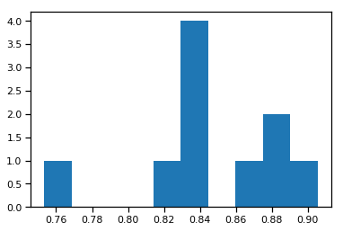

```python
plt.hist(accuracies)
plt.show()
```

```python
#Applying grid search for optimal parameters and model after k-fold validation
from sklearn.model_selection import GridSearchCV

parameters = [{'C':[0.01,0.1,1,10,50,100,500,1000], 'kernel':['rbf'], 'gamma': [0.1,0.125,0.15,0.17,0.2]}]
grid_search = GridSearchCV(estimator=classifier_svm_kernel, param_grid=parameters, scoring ='accuracy',cv=10,n_jobs=-1)
grid_search = grid_search.fit(X_train,y_train)
best_accuracy = grid_search.best_score_
best_accuracy
```

```
0.8624260355029586
```

```python
opt_param = grid_search.best_params_
opt_param
```

```
{'C': 10, 'gamma': 0.1, 'kernel': 'rbf'}
```

**It seems, that even with the optimal parameters, the accuracy is still around 0.86 with a support vector classifier. It might be interesting to study if using a different classifier might be able to give us better accuracy.**

One last thing is to see whether using just few principal components can give us similar accuracy. Hence will apply PCA and then use SVM on the few components </b>

```python
#Reloading the features and labels and normalizing them
X_train,X_test,y_train,y_test = train_test_split(X,y,test_size=0.2)
sc = StandardScaler()
X_train = sc.fit_transform(X_train)
X_test = sc.transform(X_test)

#Choosing 2 principal components
pca = PCA(n_components= 6) # here you can change this number to play around
X_train = pca.fit_transform(X_train)
X_test = pca.transform(X_test)

#Create classifier object
classifier_svm_kernel = SVC(C=5.0,kernel='rbf', gamma=0.12,tol=0.00001)
classifier_svm_kernel.fit(X_train,y_train)

# Grid search and k fold validation libraries already imported. So start the grid search
grid_search = GridSearchCV(estimator=classifier_svm_kernel, param_grid=parameters, scoring ='accuracy',cv=10,n_jobs=-1)
grid_search = grid_search.fit(X_train,y_train)

best_accuracy = grid_search.best_score_
best_accuracy
```

```
0.8579881656804734
```

**Using just 6 principal components gives an accuracy of about 1% less than all the features. Thus, it seems that most of the variance is explained by just 6 components.Lets try with different number of components**

```python
#Reloading the features and labels and normalizing them
X_train,X_test,y_train,y_test = train_test_split(X,y,test_size=0.2)
sc = StandardScaler()
X_train = sc.fit_transform(X_train)
X_test = sc.transform(X_test)

#Choosing different principal components
pca = PCA(n_components= 4) # here you can change this number to play around
X_train = pca.fit_transform(X_train)
X_test = pca.transform(X_test)

#Create classifier object
classifier_svm_kernel = SVC(C=5.0,kernel='rbf', gamma=0.12,tol=0.00001)
classifier_svm_kernel.fit(X_train,y_train)

# Grid search and k fold validation libraries already imported. So start the grid search
grid_search = GridSearchCV(estimator=classifier_svm_kernel, param_grid=parameters, scoring ='accuracy',cv=10,n_jobs=-1)
grid_search = grid_search.fit(X_train,y_train)

best_accuracy = grid_search.best_score_
best_accuracy
```

```
0.7485207100591716
```

**Conclusion:**

As reducing the components to 4 seem to be reducing the accuracy by more than 11%, it is better to stick to 6 components which gave about 85% accuracy